# Project 2 Ahmed Hassan

Ahmed Hassan

2024-10-06

Abstract: I know the assignment asked for three data sets but I am using 6. I wanted to look at specifically rent increase over the past few years in nyc. I would add a 6th data set and that is cpi or use the inflation data if rent is not a part of the cpi calculation. The goal that I am trying to accomplish in this project is artificial inflation in the rent prices. In the past three years, nyc has experienced a population decrease. So why has rent increased if the basic principals of supply and demand are to take effect and rent prices are supposed to drop as we seen in the pandemic. Is there market manipulation happening here in the rent prices? My theory is that there is an extreme amount of market manipulation. I cannot form a conclusion in my analysis in this project because this could take months upon months of research. I will however try to get an idea and form a hypothesis at the end of analysis here. Over the past couple of years, nyc has seen an increase of new residential buildings being built, especially empty and vacated land area. So I will ask the question again, why is it that rent increases when there is a decrease in population in nyc residents that is including legal and illegal residents, along with an increase in apartment units in this city if the laws of supply and demand are to be applied. Are we in a fair and free market? Let’s find out.

Part 1: Reading the data

```r
median_income_nyc_url <- "https://raw.githubusercontent.com/Ahmed572/Data607_HW_Assignments_Ahmed_Hassan/refs/heads/master/data/nyc_data/Median%20individual%20income%20in%20New%20York%20City.csv"
median_nyc_income <- read.csv(median_income_nyc_url)
head(median_nyc_income)
```

```
##     Entity.DCID Entity.properties.isoCode Entity.properties.name
## 1 geoId/3651000                        NA          New York City
## 2 geoId/3651000                        NA          New York City
## 3 geoId/3651000                        NA          New York City
## 4 geoId/3651000                        NA          New York City
## 5 geoId/3651000                        NA          New York City
## 6 geoId/3651000                        NA          New York City
##          Variable.DCID Variable.observation.date
## 1 Median_Income_Person                      2011
## 2 Median_Income_Person                      2012
## 3 Median_Income_Person                      2013
## 4 Median_Income_Person                      2014
## 5 Median_Income_Person                      2015
## 6 Median_Income_Person                      2016
##   Variable.observation.metadata.importName
```

[output cut: 41 more lines]

```r
nyc_housing_count_url <- "https://raw.githubusercontent.com/Ahmed572/Data607_HW_Assignments_Ahmed_Hassan/refs/heads/master/data/nyc_data/myc_housing_count.csv"
nyc_housing_count_data <-read.csv(nyc_housing_count_url)
head(nyc_housing_count_data)
```

```
##   placeDcid placeName Date.Count_HousingUnit Value.Count_HousingUnit
## 1 zip/10001     10001                   2011                   12161
## 2 zip/10001     10001                   2012                   12473
## 3 zip/10001     10001                   2013                   12617
## 4 zip/10001     10001                   2014                   12638
## 5 zip/10001     10001                   2015                   13305
## 6 zip/10001     10001                   2016                   13520
##                                             Source.Count_HousingUnit
## 1 https://www.census.gov/programs-surveys/acs/data/data-via-ftp.html
## 2 https://www.census.gov/programs-surveys/acs/data/data-via-ftp.html
## 3 https://www.census.gov/programs-surveys/acs/data/data-via-ftp.html
## 4 https://www.census.gov/programs-surveys/acs/data/data-via-ftp.html
## 5 https://www.census.gov/programs-surveys/acs/data/data-via-ftp.html
## 6 https://www.census.gov/programs-surveys/acs/data/data-via-ftp.html
```

```r
nyc_population_2020_2023_url <- "https://raw.githubusercontent.com/Ahmed572/Data607_HW_Assignments_Ahmed_Hassan/refs/heads/master/data/nyc_data/nyc_population_2020-2023.csv"
nyc_population_2020_2023_data <- read.csv(nyc_population_2020_2023_url)
head(nyc_population_2020_2023_data)
```

```
##             Geographic.Area April.1..2020.Estimates.Base  X2020   X2021   X2022
## 1   Adams village, New York                        1,694  1,688   1,698   1,686
## 2 Addison village, New York                        1,608  1,604   1,589   1,576
## 3   Afton village, New York                          801    800     793     792
## 4 Airmont village, New York                       10,135 10,065  10,133  10,148
## 5   Akron village, New York                        2,912  2,909   2,903   2,893
## 6     Albany city, New York                       99,239 98,682 100,710 100,884
##     X2023
## 1   1,678
## 2   1,564
## 3     786
## 4  10,163
## 5   2,883
## 6 101,228
```

```r
nyc_population_count_url <- "https://raw.githubusercontent.com/Ahmed572/Data607_HW_Assignments_Ahmed_Hassan/refs/heads/master/data/nyc_data/nyc_population_count.csv"
nyc_population_count_data <- read.csv(nyc_population_count_url)
head(nyc_population_count_data)
```

```
##   placeDcid placeName Date.Count_Person Value.Count_Person
## 1 zip/10001     10001              2011              21097
## 2 zip/10001     10001              2012              20579
## 3 zip/10001     10001              2013              21966
## 4 zip/10001     10001              2014              22767
## 5 zip/10001     10001              2015              23537
## 6 zip/10001     10001              2016              23332
##                                                  Source.Count_Person
## 1 https://www.census.gov/programs-surveys/acs/data/data-via-ftp.html
## 2 https://www.census.gov/programs-surveys/acs/data/data-via-ftp.html
## 3 https://www.census.gov/programs-surveys/acs/data/data-via-ftp.html
## 4 https://www.census.gov/programs-surveys/acs/data/data-via-ftp.html
## 5 https://www.census.gov/programs-surveys/acs/data/data-via-ftp.html
## 6 https://www.census.gov/programs-surveys/acs/data/data-via-ftp.html
```

```r
median_rent_url <- "https://raw.githubusercontent.com/Ahmed572/Data607_HW_Assignments_Ahmed_Hassan/refs/heads/master/data/nyc_data/Zip_zori_uc_sfrcondomfr_sm_month.csv"
nyc_median_rent_data <- read.csv(median_rent_url)
head(nyc_median_rent_data)
```

```
##   RegionID SizeRank RegionName RegionType StateName State     City
## 1    91982        1      77494        zip        TX    TX     Katy
## 2    91940        3      77449        zip        TX    TX     Katy
## 3    62080        4      11368        zip        NY    NY New York
## 4    91733        5      77084        zip        TX    TX  Houston
## 5    93144        6      79936        zip        TX    TX  El Paso
## 6    62093        7      11385        zip        NY    NY New York
##                                   Metro       CountyName X1.31.2015 X2.28.2015
## 1  Houston-The Woodlands-Sugar Land, TX Fort Bend County   1608.145   1612.486
## 2  Houston-The Woodlands-Sugar Land, TX    Harris County   1323.000   1318.618
## 3 New York-Newark-Jersey City, NY-NJ-PA    Queens County         NA         NA
## 4  Houston-The Woodlands-Sugar Land, TX    Harris County   1249.562   1246.504
## 5                           El Paso, TX   El Paso County         NA         NA
## 6 New York-Newark-Jersey City, NY-NJ-PA    Queens County         NA         NA
##   X3.31.2015 X4.30.2015 X5.31.2015 X6.30.2015 X7.31.2015 X8.31.2015 X9.30.2015
```

[output cut: 132 more lines]

```r
nyc_zip_code_url <- "https://raw.githubusercontent.com/Ahmed572/Data607_HW_Assignments_Ahmed_Hassan/refs/heads/master/data/nyc_data/nyc_zipcodes.csv"
nyc_zip_code_list <- read.csv(nyc_zip_code_url, header = FALSE)
nyc_zipcodes_list <- as.list(as.data.frame(t(nyc_zip_code_list)))

#print(nyc_zipcodes_list)
```

Filtering columns/Renaming columns

```r
library(dplyr)
colnames(median_nyc_income)
```

```
##  [1] "Entity.DCID"
##  [2] "Entity.properties.isoCode"
##  [3] "Entity.properties.name"
##  [4] "Variable.DCID"
##  [5] "Variable.observation.date"
##  [6] "Variable.observation.metadata.importName"
##  [7] "Variable.observation.metadata.provenanceUrl"
##  [8] "Variable.observation.metadata.scalingFactor"
##  [9] "Variable.observation.metadata.unit"
## [10] "Variable.observation.metadata.unitDisplayName"
## [11] "Variable.observation.value"
## [12] "Variable.properties.name"
```

```r
median_nyc_income <- median_nyc_income %>%
  select("Variable.observation.date", "Variable.observation.value")

median_nyc_income <- median_nyc_income %>%
  rename(
    year = Variable.observation.date,
    nyc_median_income = Variable.observation.value
  )

#print(median_nyc_income)



colnames(nyc_housing_count_data)
```

```
## [1] "placeDcid"                "placeName"
## [3] "Date.Count_HousingUnit"   "Value.Count_HousingUnit"
## [5] "Source.Count_HousingUnit"
```

```r
nyc_housing_count_data <- nyc_housing_count_data %>%
  select("placeName", "Date.Count_HousingUnit", "Value.Count_HousingUnit")
nyc_housing_count_data <- nyc_housing_count_data %>%
  rename(
    zipcode = placeName,
    year = Date.Count_HousingUnit,
    total_units = Value.Count_HousingUnit
  )
head(nyc_housing_count_data)
```

```
##   zipcode year total_units
## 1   10001 2011       12161
## 2   10001 2012       12473
## 3   10001 2013       12617
## 4   10001 2014       12638
## 5   10001 2015       13305
## 6   10001 2016       13520
```

```r
#need only one row from here and that is region = New York city, New York
colnames(nyc_population_2020_2023_data)
```

```
## [1] "Geographic.Area"              "April.1..2020.Estimates.Base"
## [3] "X2020"                        "X2021"
## [5] "X2022"                        "X2023"
```

```r
nyc_population_2020_2023_data <- nyc_population_2020_2023_data %>%
  select("Geographic.Area", "X2020", "X2021", "X2022", "X2023")

nyc_population_2020_2023_data <- nyc_population_2020_2023_data %>%
  rename(
    region = Geographic.Area,
    '2020' = X2020,
    '2021' = X2021,
    '2022' = X2022,
    '2023' = X2023
  )
#print(nyc_population_2020_2023_data)


colnames(nyc_population_count_data)
```

```
## [1] "placeDcid"           "placeName"           "Date.Count_Person"
## [4] "Value.Count_Person"  "Source.Count_Person"
```

```r
nyc_population_count_data <- nyc_population_count_data %>%
  select("placeName", "Date.Count_Person", "Value.Count_Person")

nyc_population_count_data <- nyc_population_count_data %>%
  rename(
    zipcode = placeName,
    year = Date.Count_Person,
    population_total = Value.Count_Person
  )

head(nyc_population_count_data)
```

```
##   zipcode year population_total
## 1   10001 2011            21097
## 2   10001 2012            20579
## 3   10001 2013            21966
## 4   10001 2014            22767
## 5   10001 2015            23537
## 6   10001 2016            23332
```

Transforming and merging nyc population

```r
library(tidyr)


nyc_population_2020_2023_data_filtered <- nyc_population_2020_2023_data %>%
  filter(region == "New York city, New York")

#print(nyc_population_2020_2023_data_filtered)


nyc_population2020_2023_data <- nyc_population_2020_2023_data_filtered %>%
  pivot_longer(
    cols = `2020`:`2023`,
    names_to = "year",
    values_to = "total_population"
  )

#there is no need for the region column
nyc_population2020_2023_data <- nyc_population2020_2023_data %>%
  select("year", "total_population")


nyc_population2020_2023_data <- nyc_population2020_2023_data %>%
  mutate(year = as.integer(year))

#print(nyc_population2020_2023_data)


nyc_population2020_2023_data <- nyc_population2020_2023_data %>%
  mutate(total_population = gsub("[^0-9]", "", total_population))

nyc_population2020_2023_data <- nyc_population2020_2023_data %>%
  mutate(total_population = as.integer(total_population))


nyc_population2020_2023_data <- nyc_population2020_2023_data %>%
  filter(year %in% c(2021, 2022, 2023))


#print(nyc_population2020_2023_data)





total_population_by_year <- nyc_population_count_data %>%
  group_by(year) %>%
  summarize(total_population = sum(population_total, na.rm = TRUE))


total_population_by_year <- total_population_by_year %>%
  mutate(year = as.integer(year))


total_population_by_year_filtered <- total_population_by_year %>%
  filter(!year %in% c(2021, 2022))

#print(total_population_by_year_filtered)

merged_population_data <- bind_rows(total_population_by_year_filtered, nyc_population2020_2023_data)

head(merged_population_data)
```

```
## # A tibble: 6 × 2
##    year total_population
##   <int>            <int>
## 1  2011          8122397
## 2  2012          8192973
## 3  2013          8262986
## 4  2014          8348866
## 5  2015          8420477
## 6  2016          8455824
```

graphing the total population by year from 2011 - 2023

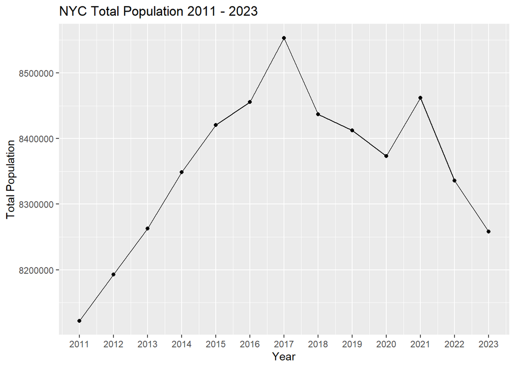

```r
library(ggplot2)
ggplot(merged_population_data, aes(x = year, y = total_population)) +
  geom_line() +
  geom_point() +
  scale_x_continuous(breaks = merged_population_data$year) +
  scale_y_continuous(breaks = seq(8000000, 8700000, by = 100000)) +
  labs(
    title = "NYC Total Population 2011 - 2023",
    x = "Year",
    y = "Total Population"
  )
```

Let me explain why I dropped the years 2021 - 2022 from the total_population_by_year df. The total population did not make sense nor was it consistent with the actual data and what was happening during that time. This was during the pandemic and people were leaving the city to either go upstate, back to other states where they were originally from to work remotely, or completley moved to other states where the cost of living was cheaper. During this time, landlords were struggling to find tenants as rent prices did drop and businesses were struggling to find employees. This was due to the laws of supply and demand. There was a shock to the renter’s market where it couldnt handle the shock of all these people leaving at once. The other dataframe that had the population from 2020 - 2023 was more accurate and consistent with other data i found online. That is why I did the filtering and merging of the two datasets the way I did. I would like to find data dating all the way back to the 1900’s for nyc population, but I found it was difficult to find this data.

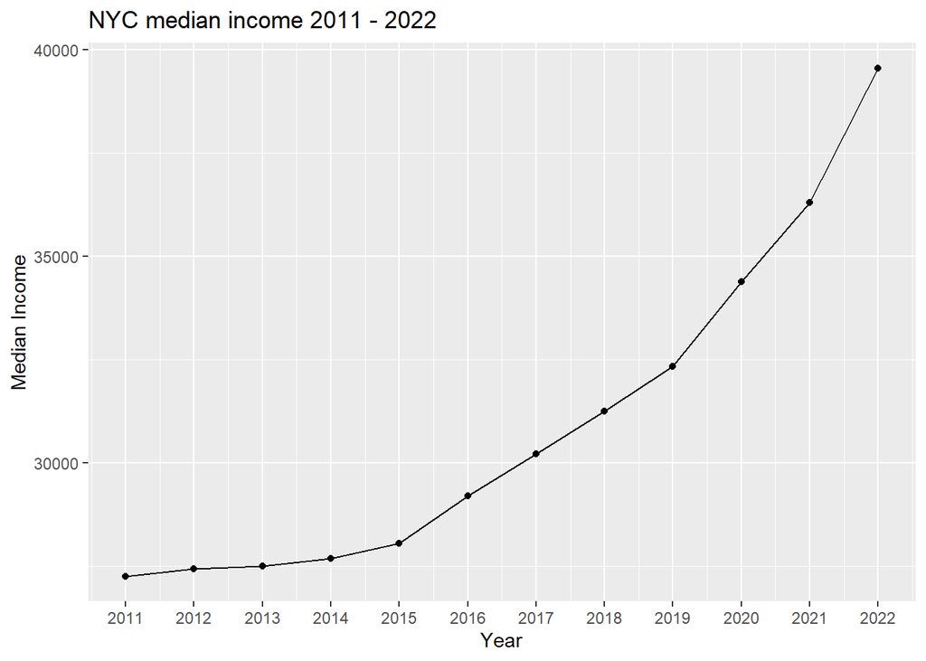

```r
ggplot(median_nyc_income, aes(x = year, y = nyc_median_income)) +
  geom_line() +
  geom_point() +
  scale_x_continuous(breaks = median_nyc_income$year) +
  labs(
    title = "NYC median income 2011 - 2022",
    x = "Year",
    y = "Median Income"
  )
```

```r
#print(median_nyc_income)
```

So comparing this chart to the population chart, we see the rise in wages but a decrease in population. Lets now start working with the suppy of housing data and do a comparison analysis.

grouping the data by year

```r
nyc_housing_count_data <- nyc_housing_count_data %>%
  group_by(year) %>%
  summarize(total_units = sum(total_units, na.rm = TRUE))


head(nyc_housing_count_data)
```

```
## # A tibble: 6 × 2
##    year total_units
##   <int>       <int>
## 1  2011     3354535
## 2  2012     3369168
## 3  2013     3378223
## 4  2014     3405660
## 5  2015     3419891
## 6  2016     3433873
```

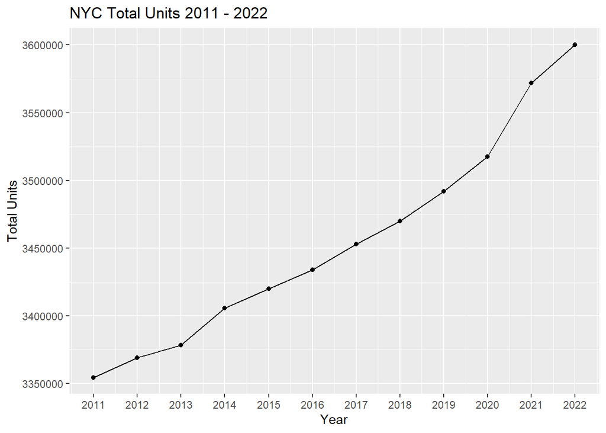

```r
ggplot(nyc_housing_count_data, aes(x = year, y = total_units)) +
  geom_line() +
  geom_point() +
  scale_x_continuous(breaks = median_nyc_income$year) +
  labs(
    title = "NYC Total Units 2011 - 2022",
    x = "Year",
    y = "Total Units"
  )
```

So far we see an increase in units, increase in wages, but a decrease in population.

Lets take a look at the median rent data. This one will be a bit tricky to work with as we are given the median rent per zipcode

```r
colnames(nyc_median_rent_data)
```

```
##   [1] "RegionID"    "SizeRank"    "RegionName"  "RegionType"  "StateName"
##   [6] "State"       "City"        "Metro"       "CountyName"  "X1.31.2015"
##  [11] "X2.28.2015"  "X3.31.2015"  "X4.30.2015"  "X5.31.2015"  "X6.30.2015"
##  [16] "X7.31.2015"  "X8.31.2015"  "X9.30.2015"  "X10.31.2015" "X11.30.2015"
##  [21] "X12.31.2015" "X1.31.2016"  "X2.29.2016"  "X3.31.2016"  "X4.30.2016"
##  [26] "X5.31.2016"  "X6.30.2016"  "X7.31.2016"  "X8.31.2016"  "X9.30.2016"
##  [31] "X10.31.2016" "X11.30.2016" "X12.31.2016" "X1.31.2017"  "X2.28.2017"
##  [36] "X3.31.2017"  "X4.30.2017"  "X5.31.2017"  "X6.30.2017"  "X7.31.2017"
##  [41] "X8.31.2017"  "X9.30.2017"  "X10.31.2017" "X11.30.2017" "X12.31.2017"
##  [46] "X1.31.2018"  "X2.28.2018"  "X3.31.2018"  "X4.30.2018"  "X5.31.2018"
##  [51] "X6.30.2018"  "X7.31.2018"  "X8.31.2018"  "X9.30.2018"  "X10.31.2018"
##  [56] "X11.30.2018" "X12.31.2018" "X1.31.2019"  "X2.28.2019"  "X3.31.2019"
##  [61] "X4.30.2019"  "X5.31.2019"  "X6.30.2019"  "X7.31.2019"  "X8.31.2019"
##  [66] "X9.30.2019"  "X10.31.2019" "X11.30.2019" "X12.31.2019" "X1.31.2020"
##  [71] "X2.29.2020"  "X3.31.2020"  "X4.30.2020"  "X5.31.2020"  "X6.30.2020"
##  [76] "X7.31.2020"  "X8.31.2020"  "X9.30.2020"  "X10.31.2020" "X11.30.2020"
##  [81] "X12.31.2020" "X1.31.2021"  "X2.28.2021"  "X3.31.2021"  "X4.30.2021"
##  [86] "X5.31.2021"  "X6.30.2021"  "X7.31.2021"  "X8.31.2021"  "X9.30.2021"
##  [91] "X10.31.2021" "X11.30.2021" "X12.31.2021" "X1.31.2022"  "X2.28.2022"
##  [96] "X3.31.2022"  "X4.30.2022"  "X5.31.2022"  "X6.30.2022"  "X7.31.2022"
## [101] "X8.31.2022"  "X9.30.2022"  "X10.31.2022" "X11.30.2022" "X12.31.2022"
## [106] "X1.31.2023"  "X2.28.2023"  "X3.31.2023"  "X4.30.2023"  "X5.31.2023"
## [111] "X6.30.2023"  "X7.31.2023"  "X8.31.2023"  "X9.30.2023"  "X10.31.2023"
## [116] "X11.30.2023" "X12.31.2023" "X1.31.2024"  "X2.29.2024"  "X3.31.2024"
## [121] "X4.30.2024"  "X5.31.2024"  "X6.30.2024"  "X7.31.2024"  "X8.31.2024"
```

```r
nyc_zipcodes_vector <- unlist(nyc_zipcodes_list)

filtered_rent_data <- nyc_median_rent_data %>%
  filter(RegionName %in% nyc_zipcodes_vector)

head(filtered_rent_data)
```

```
##   RegionID SizeRank RegionName RegionType StateName State     City
## 1    62080        4      11368        zip        NY    NY New York
## 2    62093        7      11385        zip        NY    NY New York
## 3    62019        9      11208        zip        NY    NY New York
## 4    62046       16      11236        zip        NY    NY New York
## 5    61807       17      10467        zip        NY    NY New York
## 6    62085       18      11373        zip        NY    NY New York
##                                   Metro    CountyName X1.31.2015 X2.28.2015
## 1 New York-Newark-Jersey City, NY-NJ-PA Queens County         NA         NA
## 2 New York-Newark-Jersey City, NY-NJ-PA Queens County         NA         NA
## 3 New York-Newark-Jersey City, NY-NJ-PA  Kings County         NA         NA
## 4 New York-Newark-Jersey City, NY-NJ-PA  Kings County         NA         NA
## 5 New York-Newark-Jersey City, NY-NJ-PA  Bronx County         NA         NA
## 6 New York-Newark-Jersey City, NY-NJ-PA Queens County         NA         NA
##   X3.31.2015 X4.30.2015 X5.31.2015 X6.30.2015 X7.31.2015 X8.31.2015 X9.30.2015
```

[output cut: 132 more lines]

```r
#creating a new df and taking the median of each date column

date_columns <- colnames(filtered_rent_data)[grepl("^X", colnames(filtered_rent_data))]

average_rent_nyc_df <- data.frame(
  Date = gsub("^X", "", date_columns),  # Remove the "X" from the column names to get the date
  Median = sapply(filtered_rent_data[, date_columns], median, na.rm = TRUE)  # Compute the median for each date column
)
average_rent_nyc_df$Mean <- sapply(filtered_rent_data[, date_columns], mean, na.rm = TRUE)


average_rent_nyc_df$Date <- as.Date(average_rent_nyc_df$Date, format = "%m.%d.%Y")

head(average_rent_nyc_df)
```

```
##                  Date   Median     Mean
## X1.31.2015 2015-01-31 2732.498 2727.223
## X2.28.2015 2015-02-28 2706.051 2726.790
## X3.31.2015 2015-03-31 2662.657 2722.277
## X4.30.2015 2015-04-30 2664.783 2725.026
## X5.31.2015 2015-05-31 2694.550 2733.493
## X6.30.2015 2015-06-30 2723.866 2739.232
```

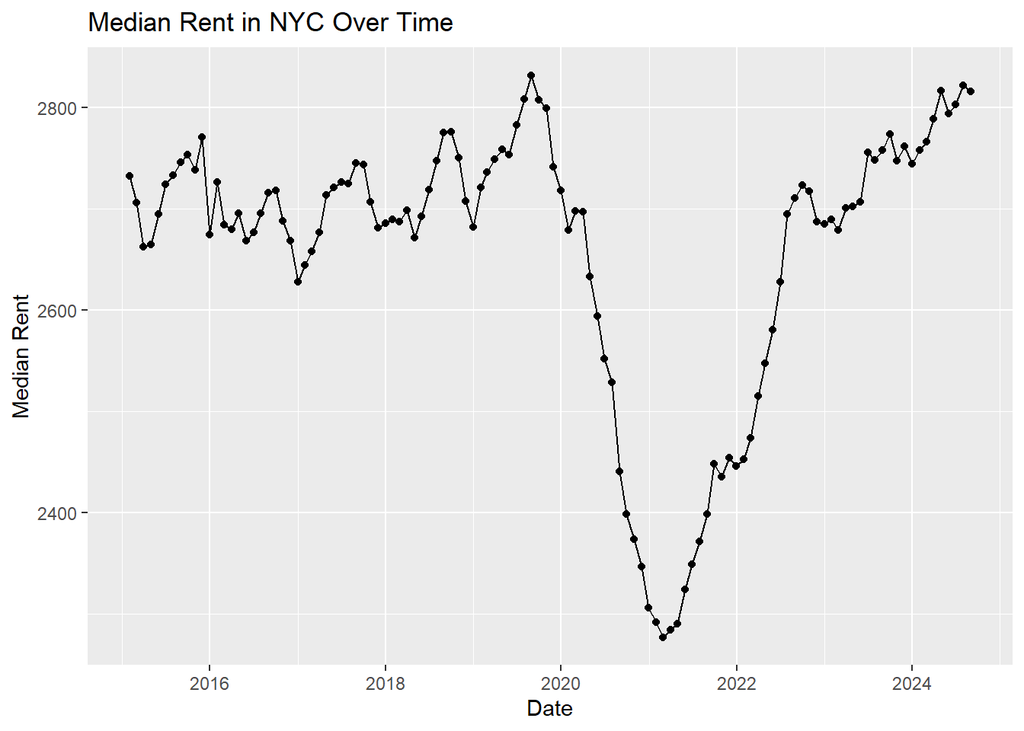

```r
ggplot(average_rent_nyc_df, aes(x = Date, y = Median)) +
  geom_line() +  # Line plot to connect the points
  geom_point() +  # Add points at each date
  labs(title = "Median Rent in NYC Over Time",
       x = "Date",
       y = "Median Rent")
```

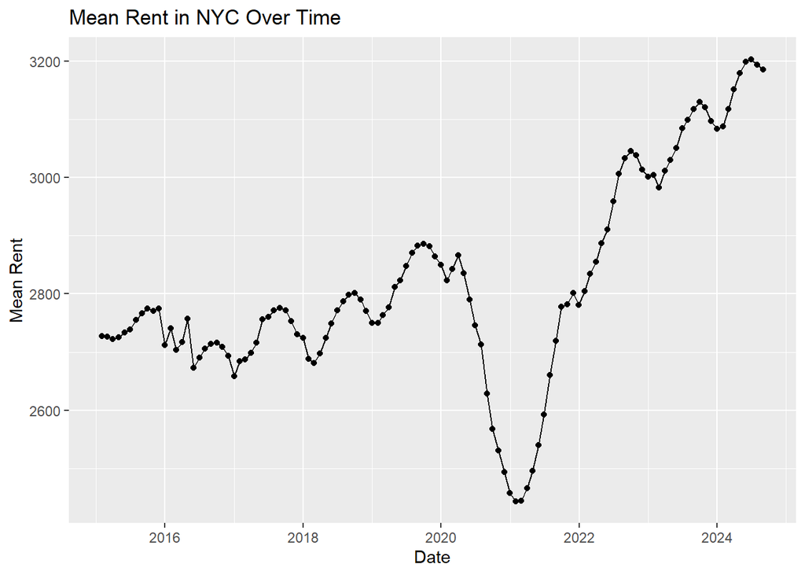

```r
ggplot(average_rent_nyc_df, aes(x = Date, y = Mean)) +
  geom_line() +  # Line plot to connect the points
  geom_point() +  # Add points at each date
  labs(title = "Mean Rent in NYC Over Time",
       x = "Date",
       y = "Mean Rent")
```

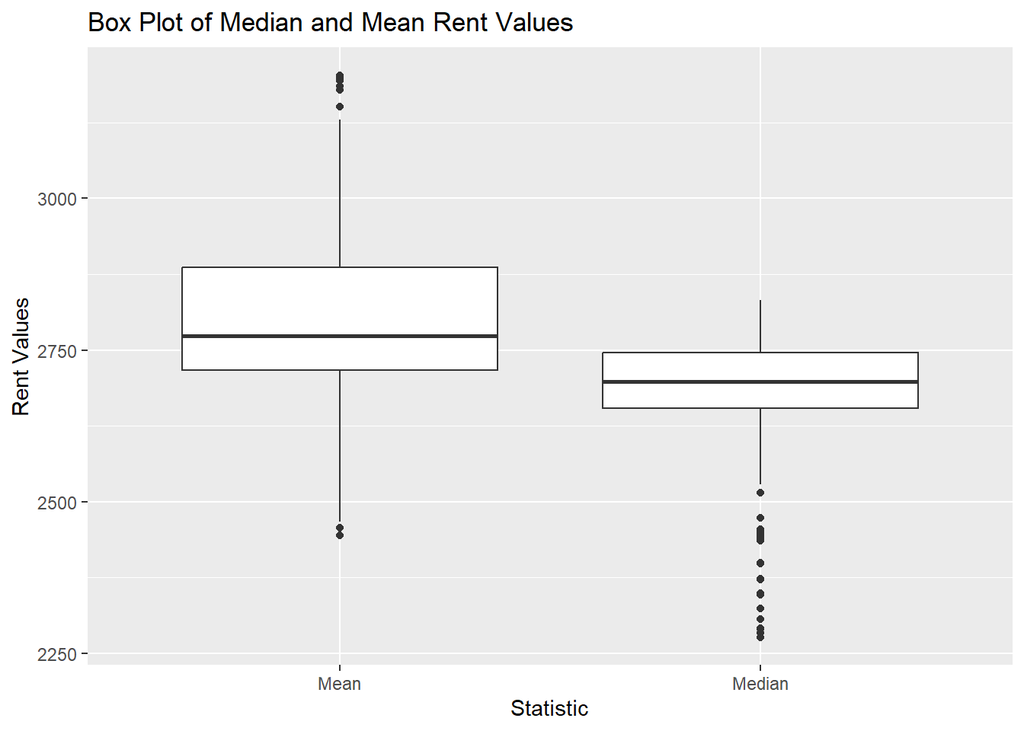

```r
long_average_rent_nyc_df <- pivot_longer(average_rent_nyc_df,
                               cols = c("Median", "Mean"),
                               names_to = "Statistic",
                               values_to = "Value")

ggplot(long_average_rent_nyc_df, aes(x = Statistic, y = Value)) +
  geom_boxplot() +
  labs(title = "Box Plot of Median and Mean Rent Values",
       x = "Statistic",
       y = "Rent Values")
```

```r
#colnames(filtered_rent_data) <- ifelse(grepl("^X", colnames(filtered_rent_data)), gsub("^X", "", #colnames(filtered_rent_data)), colnames(filtered_rent_data))





#nyc_median_rent_data <- nyc_median_rent_data %>%
#  select("placeName", "Date.Monthly_Median_GrossRent_HousingUnit", "Value.Monthly_Median_GrossRent_HousingUnit")
#nyc_median_rent_data <- nyc_median_rent_data %>%
#  rename(
#    zipcode = placeName,
#    year = Date.Monthly_Median_GrossRent_HousingUnit,
#    median_gross_rent = Value.Monthly_Median_GrossRent_HousingUnit
#  )


#print(nyc_zipcodes_list)

#head(nyc_median_rent_data)
```

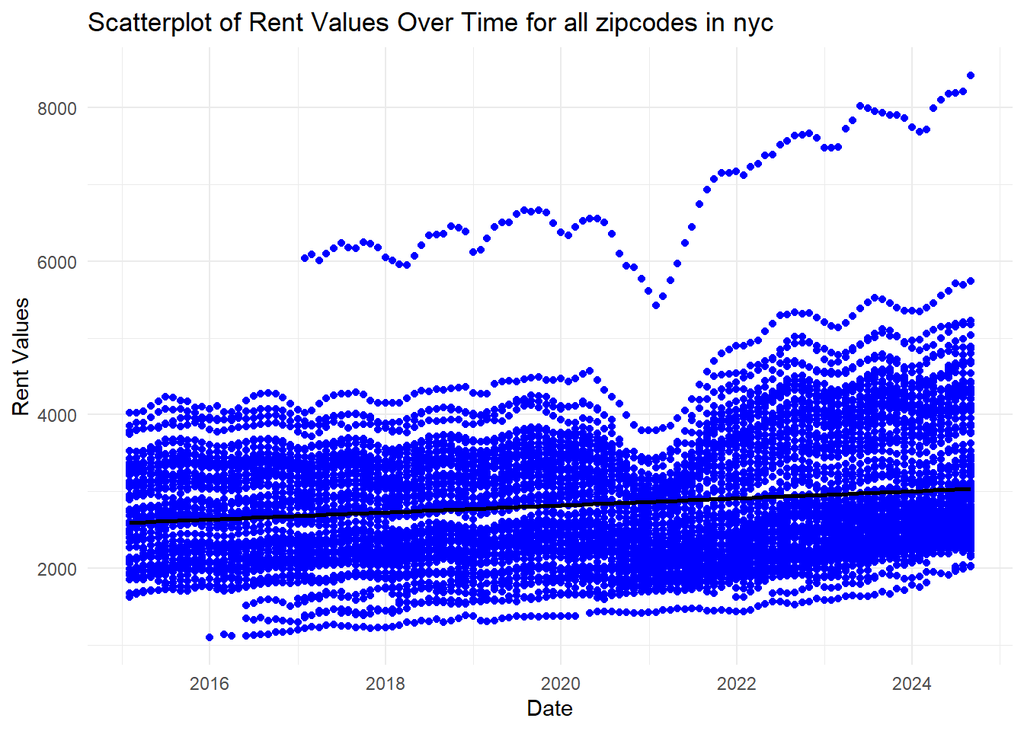

```r
long_rent_data <- pivot_longer(filtered_rent_data,
                               cols = starts_with("X"),
                               names_to = "Date",
                               values_to = "Rent")

long_rent_data$Date <- gsub("^X", "", long_rent_data$Date)

# Convert the Date column to proper date format
long_rent_data$Date <- as.Date(long_rent_data$Date, format = "%m.%d.%Y")


ggplot(long_rent_data, aes(x = Date, y = Rent)) +
  geom_point(color = "blue") +
  geom_smooth(method = "lm", se = FALSE, color = "black") +
  labs(title = "Scatterplot of Rent Values Over Time for all zipcodes in nyc",
       x = "Date",
       y = "Rent Values") +
  theme_minimal()
```

We did have a lot of people return to nyc and return to the office since the start of 2023. However we still got a decrease in population. I would even argue a decrease in white colar wages, although I would need to add a 7th data set here to confirm. I am making the case for the decrease in wages because I was unemployed for 3 months this year, and I was applying, the jobs postings had a less hourly rate than they did back during the pandemic or even in 2019. If I were to go into more debth for this I would go look into vacant apartment units vs nonvacant in 2022-2024. The reason for this is that I want to confirm what is being told on the news with landlords keeping units vacant on purpose in order to drive up the rent prices. I would also try to look for salaries of white colar workers in nyc to see if they are also driving up the rent prices.

I want to add one final note about something I observed in real life that is not part of the data. Over the past 5 years I have seen many new construction of high rise buildings all around queens and brooklyn. I would also belive that the dataset for the total units are being under counted in the city.